# R Notebook

# Task 1

1 MVP

We’ve looked at a few different ways in which we can build models this week, including how to prepare them properly. This weekend we’ll build a multiple linear regression model on a dataset which will need some preparation. The data can be found in the data folder, along with a data dictionary

We want to investigate the wine_quality_red and wine_quality_white datasets, and, in particular, to model the quality of the wines. Use regression to determine which physiochemical properties make a wine ‘good’!

Use the tools we’ve worked with this week in order to prepare your dataset and find appropriate predictors. Once you’ve built your model use the validation techniques discussed on Wednesday to evaluate it. Feel free to focus either on building an explanatory or a predictive model, or both if you are feeling energetic!

Acknowledgements This dataset is from the UCI machine learning repository, https://archive.ics.uci.edu/ml/datasets/wine+quality.

Ref: P. Cortez, A. Cerdeira, F. Almeida, T. Matos and J. Reis. Modeling wine preferences by data mining from physicochemical properties. In Decision Support Systems, Elsevier, 47(4):547-553, 2009.

As part of the MVP we want you not to just run the code but also have a go at interpreting the results and write your thinking in comments in your script.

Hints and tips

region may lead to many dummy variables. Think carefully about whether to include this variable or not (there is no one ‘right’ answer to this!)

Think about whether each variable is categorical or numerical. If categorical, make sure that the variable is represented as a factor.

If you want to build a predictive model, consider using either leaps or glmulti to help with this.

```r
library(tidyverse)
library(ggplot2)
library(GGally)
library(psych)
library(leaps)
```

```r
red <- read_csv("data/wine_quality_red.csv")
white <- read_csv("data/wine_quality_white.csv")
```

```r
skimr::skim(red)
```

```
── Data Summary ────────────────────────
                           Values
Name                       red
Number of rows             1599
Number of columns          14
_______________________
Column type frequency:
  character                1
  numeric                  13
________________________
Group variables            None
```

|  | skim_variable | n_missing | complete_rate | min | max | empty | n_unique | whitespace |
| --- | --- | --- | --- | --- | --- | --- | --- | --- |
| 1 | region | 0 | 1 | 3 | 9 | 0 | 5 | 0 |

|  | skim_variable | n_missing | complete_rate | mean | sd | p0 | p25 | p50 | p75 | p100 | hist |
| --- | --- | --- | --- | --- | --- | --- | --- | --- | --- | --- | --- |
| 1 | wine_id | 0 | 1 | 800.00000000 | 4.617359e+02 | 1.00000 | 400.5000 | 800.00000 | 1199.500000 | 1599.00000 | ▇▇▇▇▇ |
| 2 | fixed_acidity | 0 | 1 | 8.31963727 | 1.741096e+00 | 4.60000 | 7.1000 | 7.90000 | 9.200000 | 15.90000 | ▂▇▂▁▁ |
| 3 | volatile_acidity | 0 | 1 | 0.52782051 | 1.790597e-01 | 0.12000 | 0.3900 | 0.52000 | 0.640000 | 1.58000 | ▅▇▂▁▁ |
| 4 | citric_acid | 0 | 1 | 0.27097561 | 1.948011e-01 | 0.00000 | 0.0900 | 0.26000 | 0.420000 | 1.00000 | ▇▆▅▁▁ |
| 5 | residual_sugar | 0 | 1 | 2.53880550 | 1.409928e+00 | 0.90000 | 1.9000 | 2.20000 | 2.600000 | 15.50000 | ▇▁▁▁▁ |
| 6 | chlorides | 0 | 1 | 0.08746654 | 4.706530e-02 | 0.01200 | 0.0700 | 0.07900 | 0.090000 | 0.61100 | ▇▁▁▁▁ |
| 7 | free_sulfur_dioxide | 0 | 1 | 15.87492183 | 1.046016e+01 | 1.00000 | 7.0000 | 14.00000 | 21.000000 | 72.00000 | ▇▅▁▁▁ |
| 8 | total_sulfur_dioxide | 0 | 1 | 46.46779237 | 3.289532e+01 | 6.00000 | 22.0000 | 38.00000 | 62.000000 | 289.00000 | ▇▂▁▁▁ |
| 9 | density | 0 | 1 | 0.99674668 | 1.887334e-03 | 0.99007 | 0.9956 | 0.99675 | 0.997835 | 1.00369 | ▁▃▇▂▁ |
| 10 | p_h | 0 | 1 | 3.31111320 | 1.543865e-01 | 2.74000 | 3.2100 | 3.31000 | 3.400000 | 4.01000 | ▁▅▇▂▁ |

[output cut: 3 more lines]

```r
skimr::skim(white)
```

```
── Data Summary ────────────────────────
                           Values
Name                       white
Number of rows             4898
Number of columns          14
_______________________
Column type frequency:
  character                1
  numeric                  13
________________________
Group variables            None
```

|  | skim_variable | n_missing | complete_rate | min | max | empty | n_unique | whitespace |
| --- | --- | --- | --- | --- | --- | --- | --- | --- |
| 1 | region | 0 | 1 | 3 | 9 | 0 | 5 | 0 |

|  | skim_variable | n_missing | complete_rate | mean | sd | p0 | p25 | p50 | p75 | p100 | hist |
| --- | --- | --- | --- | --- | --- | --- | --- | --- | --- | --- | --- |
| 1 | wine_id | 0 | 1 | 2.449500e+03 | 1.414075e+03 | 1.00000 | 1225.2500000 | 2449.50000 | 3673.7500 | 4898.00000 | ▇▇▇▇▇ |
| 2 | fixed_acidity | 0 | 1 | 6.854788e+00 | 8.438682e-01 | 3.80000 | 6.3000000 | 6.80000 | 7.3000 | 14.20000 | ▁▇▁▁▁ |
| 3 | volatile_acidity | 0 | 1 | 2.782411e-01 | 1.007945e-01 | 0.08000 | 0.2100000 | 0.26000 | 0.3200 | 1.10000 | ▇▅▁▁▁ |
| 4 | citric_acid | 0 | 1 | 3.341915e-01 | 1.210198e-01 | 0.00000 | 0.2700000 | 0.32000 | 0.3900 | 1.66000 | ▇▆▁▁▁ |
| 5 | residual_sugar | 0 | 1 | 6.391415e+00 | 5.072058e+00 | 0.60000 | 1.7000000 | 5.20000 | 9.9000 | 65.80000 | ▇▁▁▁▁ |
| 6 | chlorides | 0 | 1 | 4.577236e-02 | 2.184797e-02 | 0.00900 | 0.0360000 | 0.04300 | 0.0500 | 0.34600 | ▇▁▁▁▁ |
| 7 | free_sulfur_dioxide | 0 | 1 | 3.530808e+01 | 1.700714e+01 | 2.00000 | 23.0000000 | 34.00000 | 46.0000 | 289.00000 | ▇▁▁▁▁ |
| 8 | total_sulfur_dioxide | 0 | 1 | 1.383607e+02 | 4.249806e+01 | 9.00000 | 108.0000000 | 134.00000 | 167.0000 | 440.00000 | ▂▇▂▁▁ |
| 9 | density | 0 | 1 | 9.940274e-01 | 2.990907e-03 | 0.98711 | 0.9917225 | 0.99374 | 0.9961 | 1.03898 | ▇▂▁▁▁ |
| 10 | p_h | 0 | 1 | 3.188267e+00 | 1.510006e-01 | 2.72000 | 3.0900000 | 3.18000 | 3.2800 | 3.82000 | ▁▇▇▂▁ |

[output cut: 3 more lines]

```r
view(red)
view(white)
```

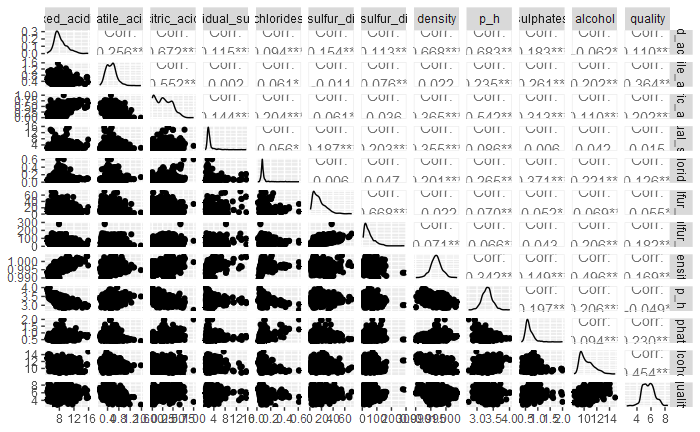

```r
# tidying before checkign for correlations wiht gg pairs

red_clean <- red %>%
  select(-wine_id,-region)

red_clean%>%
  ggpairs()
```

```r
# hard to read i am just cecking cor at this point and quite like the corplot from psych so using that
```

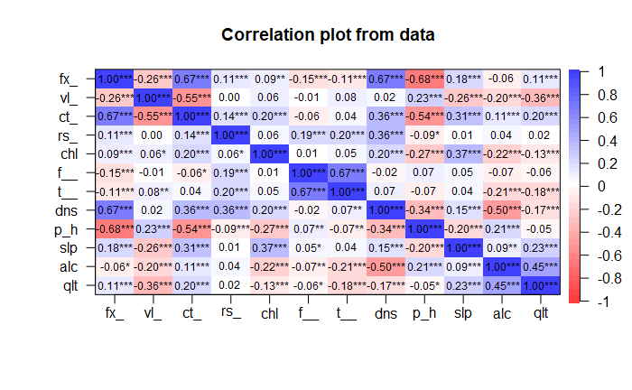

```r
cor.plot(red_clean, min.length = 3, stars = TRUE) # going to use alc, volatile acidity, sulphates, and citric acid. will be using adjusted r squared as validation here. will include a second model with more predictors and compare the adjusted r squared. These are my initial thoughts but will start with all and work backwards.
```

```r
#initial thoughts

mod1 <- lm(quality ~ alcohol + volatile_acidity + sulphates + citric_acid, data = red_clean )
mod2 <- lm(quality ~ alcohol + volatile_acidity + sulphates + citric_acid + total_sulfur_dioxide, data = red_clean )

summary(mod1)
```

```
Call:
lm(formula = quality ~ alcohol + volatile_acidity + sulphates +
    citric_acid, data = red_clean)

Residuals:
     Min       1Q   Median       3Q      Max
-2.65578 -0.45093 -0.00829  0.47965  2.14207

Coefficients:
                 Estimate Std. Error t value Pr(>|t|)
(Intercept)       2.68788    0.21707  12.382  < 2e-16 ***
alcohol           0.31110    0.01707  18.228  < 2e-16 ***
volatile_acidity -1.26792    0.12164 -10.424  < 2e-16 ***
sulphates         0.66492    0.11132   5.973 2.87e-09 ***
citric_acid      -0.13321    0.11208  -1.189    0.235
---
Signif. codes:  0 ‘***’ 0.001 ‘**’ 0.01 ‘*’ 0.05 ‘.’ 0.1 ‘ ’ 1

Residual standard error: 0.7113 on 1594 degrees of freedom
Multiple R-squared:  0.2991,    Adjusted R-squared:  0.2974
F-statistic: 170.1 on 4 and 1594 DF,  p-value: < 2.2e-16
```

```r
summary(mod2)
```

```
Call:
lm(formula = quality ~ alcohol + volatile_acidity + sulphates +
    citric_acid + total_sulfur_dioxide, data = red_clean)

Residuals:
     Min       1Q   Median       3Q      Max
-2.66691 -0.45044  0.00732  0.47146  2.11065

Coefficients:
                       Estimate Std. Error t value Pr(>|t|)
(Intercept)           2.8957848  0.2214719  13.075  < 2e-16 ***
alcohol               0.2966178  0.0173199  17.126  < 2e-16 ***
volatile_acidity     -1.2228468  0.1214716 -10.067  < 2e-16 ***
sulphates             0.6915668  0.1109166   6.235 5.77e-10 ***
citric_acid          -0.0948346  0.1118639  -0.848    0.397
total_sulfur_dioxide -0.0023387  0.0005536  -4.225 2.53e-05 ***
---
Signif. codes:  0 ‘***’ 0.001 ‘**’ 0.01 ‘*’ 0.05 ‘.’ 0.1 ‘ ’ 1

Residual standard error: 0.7076 on 1593 degrees of freedom
Multiple R-squared:  0.3069,    Adjusted R-squared:  0.3047
F-statistic: 141.1 on 5 and 1593 DF,  p-value: < 2.2e-16
```

```r
#goign to swap citric with total sulfur dioxide as it was more significant

mod1 <- lm(quality ~ alcohol + volatile_acidity + sulphates + total_sulfur_dioxide, data = red_clean )
summary(mod3)
```

[output not shown]

```
Error: object 'mod3' not found
```

```r
summary(leapmod)
```

```
Call:
lm(formula = quality ~ volatile_acidity + chlorides + total_sulfur_dioxide +
    p_h + sulphates + alcohol, data = red_clean)

Residuals:
     Min       1Q   Median       3Q      Max
-2.60377 -0.44609  0.00536  0.47012  2.11975

Coefficients:
                       Estimate Std. Error t value Pr(>|t|)
(Intercept)           4.2934690  0.4322960   9.932  < 2e-16 ***
volatile_acidity     -1.0123194  0.1086549  -9.317  < 2e-16 ***
chlorides            -2.0010744  0.4306896  -4.646 3.66e-06 ***
total_sulfur_dioxide -0.0025122  0.0005479  -4.585 4.89e-06 ***
p_h                  -0.4235327  0.1255436  -3.374  0.00076 ***
sulphates             0.8504138  0.1190575   7.143 1.39e-12 ***
alcohol               0.2914758  0.0181881  16.026  < 2e-16 ***
---
Signif. codes:  0 ‘***’ 0.001 ‘**’ 0.01 ‘*’ 0.05 ‘.’ 0.1 ‘ ’ 1

Residual standard error: 0.7018 on 1592 degrees of freedom
Multiple R-squared:  0.3185,    Adjusted R-squared:  0.3159
F-statistic:   124 on 6 and 1592 DF,  p-value: < 2.2e-16
```

## Task 2

I want to predict how well 6 year-olds are going to do in their final school exams. Using the following variables am I likely under-fitting, fitting well or over-fitting? Postcode, gender, reading level, score in maths test, date of birth, family income.

> Likely over fitting, gender seems like it wouldnt correlate with exam scores and, as the exam participants fall within the same birth year, it may lead to accurate predictions within the original data but may impact the ability to predict scores in other exams where the ages are different.

If I have two models, one with an AIC score of 34,902 and the other with an AIC score of 33,559 which model should I use?

> Using AIC the best-fit model is the one that explains the greatest amount of variation using the fewest possible independent variables. The lower score is better and should be used.

I have two models, the first with: r-squared: 0.44, adjusted r-squared: 0.43. The second with: r-squared: 0.47, adjusted r-squared: 0.41. Which one should I use?

> I would use the first model as the adjusted r-squared is higher even though the r-squared is higher. R-squared will always increase as mor epredictors are used however adjusted r-squared penalises over using predictors. It is likely the second is overfit and may better predict within the original data but be outperformed by th eother model with new data.

I have a model with the following errors: RMSE error on test set: 10.3, RMSE error on training data: 10.4. Do you think this model is over-fitting?

> I don’t think so as the model is performing slightly better on the unseen test data.

How does k-fold validation work?

> Data is divided or folded randomly into k groups and one is used as the test set and the others for trianining. You then make the model from the trianing set then evaluate the performance on th etest set. The groups stay unique throughout allowing you to cycle through so that each set is “used as the”held out”. All data is the nused in testing and trianing. 10 folds is a set norm however it is not a rule. If the data is small too many “fold” could mean each set is no longer a true representation of the whole so fewer should be used.

What is a validation set? When do you need one?

> A validation set is used to optimise the model before evaluting on the test set. Keeping it seperate from the unseen data is important so the test scores stay as accurate as possible. (unsure of this)

Describe how backwards selection works.

> The model begins with all possible predictors and they are removed one by one to keep it simple while improving its performance.

Describe how best subset selection works.

> In best subset selection all possible combinations of predictors are considered and the best performing subset is chosen. This is ideal however not always possible if the data is too large. It is possible to do it automatically but again if th edata is too large computing power could become a problem.

jamie below

```r
n_data_white <- nrow(white)
test_prop <- 0.1
test_index_white <- sample(1:n_data_white, size = n_data_white* test_prop)
test_white <- slice(white, test_index_white)
train_white <- slice(white, -test_index_white)
```

[output not shown]